```python
import pandas as pd
import numpy as np
import seaborn as sns
import statsmodels.api as sm
import matplotlib.pyplot as plt
import matplotlib
from datetime import datetime, timedelta

from matplotlib import font_manager, rc, cm
%matplotlib inline

import platform
your_os = platform.system()
if your_os == 'Linux':
    rc('font', family='NanumGothic')
elif your_os == 'Windows':
    ttf = "c:/Windows/Fonts/malgun.ttf"
    font_name = font_manager.FontProperties(fname=ttf).get_name()
    rc('font', family=font_name)
elif your_os == 'Darwin':
    rc('font', family='AppleGothic')
rc('axes', unicode_minus=False)
from sklearn.model_selection import train_test_split
import glob
import os
import time
import random
import warnings; warnings.filterwarnings("ignore")
from IPython.display import Image
import pickle
from tqdm import tqdm
import platform
from itertools import combinations
from scipy.stats.mstats import gmean

from tqdm.notebook import tqdm
from pycaret.regression import *
from sklearn.metrics import mean_squared_error
from sklearn.metrics import r2_score
```

# 데이터 스케일링 하기

- 컬럼 하나마다 기준값이 달라진다

```python
import pandas as pd
from sklearn.preprocessing import MinMaxScaler
```

```python
data = pd.read_csv("val.csv").drop("ID",axis=1)
```

```python
data.head()
```

|  | V1 | V2 | V3 | V4 | V5 | V6 | V7 | V8 | V9 | V10 | ... | V22 | V23 | V24 | V25 | V26 | V27 | V28 | V29 | V30 | Class |
| --- | --- | --- | --- | --- | --- | --- | --- | --- | --- | --- | --- | --- | --- | --- | --- | --- | --- | --- | --- | --- | --- |
| 0 | -0.338262 | 1.119593 | 1.044367 | -0.222187 | 0.499361 | -0.246761 | 0.651583 | 0.069539 | -0.736727 | -0.366846 | ... | -0.633753 | -0.120794 | -0.385050 | -0.069733 | 0.094199 | 0.246219 | 0.083076 | -0.255991 | -0.994878 | 0 |
| 1 | 0.962496 | 0.328461 | -0.171479 | 2.109204 | 1.129566 | 1.696038 | 0.107712 | 0.521502 | -1.191311 | 0.724396 | ... | 0.402492 | -0.048508 | -1.371866 | 0.390814 | 0.199964 | 0.016371 | -0.014605 | 0.168937 | -0.994784 | 0 |
| 2 | 1.145524 | 0.575068 | 0.194008 | 2.598192 | -0.092210 | -1.044430 | 0.531588 | -0.241888 | -0.896287 | 0.757952 | ... | -0.119703 | -0.076510 | 0.691320 | 0.633984 | 0.048741 | -0.053192 | 0.016251 | 0.169496 | -0.994502 | 0 |
| 3 | 0.927060 | -0.323684 | 0.387585 | 0.544474 | 0.246787 | 1.650358 | -0.427576 | 0.615371 | 0.226278 | -0.225495 | ... | 0.079359 | 0.096632 | -0.992569 | 0.085096 | 0.377447 | 0.036096 | -0.005960 | 0.331307 | -0.994467 | 0 |
| 4 | -3.005237 | 2.600138 | 1.483691 | -2.418473 | 0.306326 | -0.824575 | 2.065426 | -1.829347 | 4.009259 | 6.051521 | ... | -0.181268 | -0.163747 | 0.515821 | 0.136318 | 0.460054 | -0.251259 | -1.105751 | -0.287012 | -0.994373 | 0 |

5 rows × 31 columns

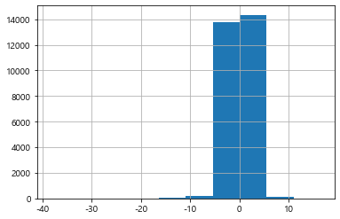

```python
data["V2"].hist()
```

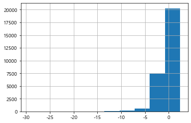

```python
data["V1"].hist()
```

```python
for col in data.columns:

    scaler = MinMaxScaler()

    data[col] = scaler.fit_transform(data[col].values.reshape(-1,1))
```

```python
scaler = MinMaxScaler()

for col in data.columns:

    data[col] = scaler.fit_transform(data[col].values.reshape(-1,1))
```

```python
data.head()
```

|  | V1 | V2 | V3 | V4 | V5 | V6 | V7 | V8 | V9 | V10 | ... | V22 | V23 | V24 | V25 | V26 | V27 | V28 | V29 | V30 | Class |
| --- | --- | --- | --- | --- | --- | --- | --- | --- | --- | --- | --- | --- | --- | --- | --- | --- | --- | --- | --- | --- | --- |
| 0 | 0.913867 | 0.719396 | 0.907517 | 0.282153 | 0.480733 | 0.562720 | 0.554520 | 0.680654 | 0.501486 | 0.635252 | ... | 0.540890 | 0.569616 | 0.374668 | 0.516025 | 0.362467 | 0.542617 | 0.350658 | 0.000309 | 0.000000 | 0.0 |
| 1 | 0.954608 | 0.704960 | 0.872176 | 0.417810 | 0.494456 | 0.631366 | 0.545051 | 0.692330 | 0.475360 | 0.667021 | ... | 0.611642 | 0.571247 | 0.222067 | 0.555864 | 0.385142 | 0.530194 | 0.346603 | 0.002865 | 0.000046 | 0.0 |
| 2 | 0.960340 | 0.709460 | 0.882799 | 0.446263 | 0.467851 | 0.534535 | 0.552431 | 0.672609 | 0.492316 | 0.667998 | ... | 0.575988 | 0.570615 | 0.541118 | 0.576899 | 0.352721 | 0.526435 | 0.347884 | 0.002869 | 0.000185 | 0.0 |
| 3 | 0.953498 | 0.693060 | 0.888426 | 0.326763 | 0.475233 | 0.629752 | 0.535731 | 0.694755 | 0.556831 | 0.639367 | ... | 0.589579 | 0.574523 | 0.280722 | 0.529418 | 0.423193 | 0.531260 | 0.346962 | 0.003842 | 0.000203 | 0.0 |
| 4 | 0.830336 | 0.746412 | 0.920286 | 0.154357 | 0.476530 | 0.542304 | 0.579137 | 0.631599 | 0.774244 | 0.822109 | ... | 0.571784 | 0.568646 | 0.513979 | 0.533849 | 0.440903 | 0.515730 | 0.301312 | 0.000123 | 0.000249 | 0.0 |

5 rows × 31 columns

```python
data["V1"].describe()
```

```
count    28462.000000
mean         0.924618
std          0.060469
min          0.000000
25%          0.895787
50%          0.925201
75%          0.965667
max          1.000000
Name: V1, dtype: float64
```

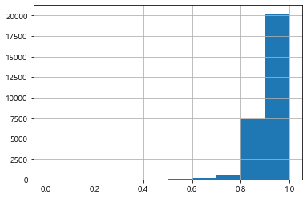

```python
data["V1"].hist()
```

# 상관관계 확인과 VIF

- 상관관계를 확인하고 변수 줄이기

```python
import matplotlib.pyplot as plt
import seaborn as sns
```

pairplot 그리기

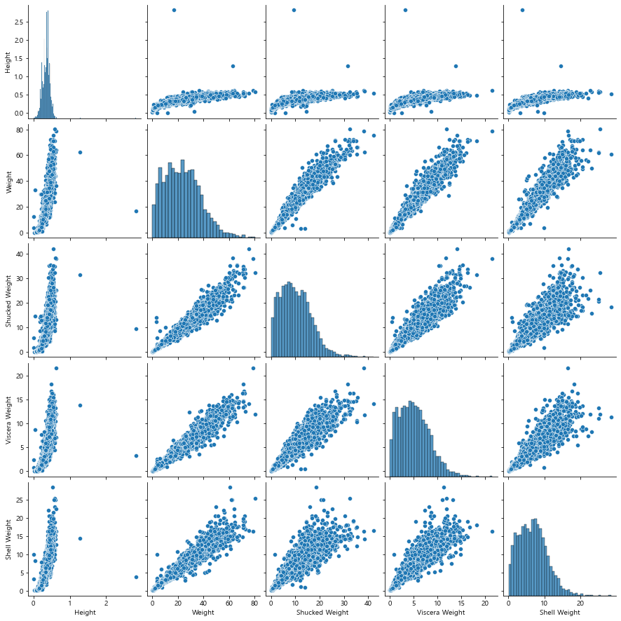

```python
df = pd.read_csv('CrabAgePrediction.csv')

sns.pairplot(df[['Height', 'Weight', 'Shucked Weight', 'Viscera Weight', 'Shell Weight']])
plt.show()
```

가장 왼쪽 컬럼에 있는 height 말고는 상관관계가 커 보인다 -> 다중공선성 문제가 발생할 수 있음

- 다중공선성 문제가 있는 변수들을 제거하지 않고 회귀분석을 진행
- intercept는 절편

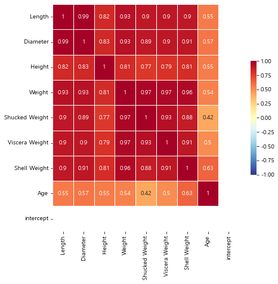

```python
corr_df = df.corr()
# 그림 사이즈 지정
fig, ax = plt.subplots( figsize=(7,7) )

# 삼각형 마스크를 만든다(위 쪽 삼각형에 True, 아래 삼각형에 False)
mask = np.zeros_like(corr_df, dtype=np.bool)
mask[np.triu_indices_from(mask)] = False

# 히트맵을 그린다
sns.heatmap(corr_df,
            cmap = 'RdYlBu_r',
            annot = True,   # 실제 값을 표시한다
            mask=mask,      # 표시하지 않을 마스크 부분을 지정한다
            linewidths=.5,  # 경계면 실선으로 구분하기
            cbar_kws={"shrink": .5},# 컬러바 크기 절반으로 줄이기
            vmin = -1,vmax = 1   # 컬러바 범위 -1 ~ 1
           )
plt.show()
```

```python
import pandas as pd
import statsmodels.api as sm;

df['intercept'] = 1
model = sm.OLS(df['Age'], df[['intercept', 'Height', 'Weight',
                           'Shucked Weight', 'Viscera Weight', 'Shell Weight']])
results = model.fit()
print(results.summary())
```

```
                            OLS Regression Results
==============================================================================
Dep. Variable:                    Age   R-squared:                       0.509
Model:                            OLS   Adj. R-squared:                  0.508
Method:                 Least Squares   F-statistic:                     805.6
Date:                Sun, 17 Jul 2022   Prob (F-statistic):               0.00
Time:                        19:37:36   Log-Likelihood:                -8692.8
No. Observations:                3893   AIC:                         1.740e+04
Df Residuals:                    3887   BIC:                         1.744e+04
Df Model:                           5
Covariance Type:            nonrobust
==================================================================================
                     coef    std err          t      P>|t|      [0.025      0.975]
----------------------------------------------------------------------------------
intercept          5.4021      0.142     38.154      0.000       5.125       5.680
Height             6.8135      0.609     11.185      0.000       5.619       8.008
Weight             0.3351      0.027     12.457      0.000       0.282       0.388
Shucked Weight    -0.6748      0.030    -22.498      0.000      -0.734      -0.616
Viscera Weight    -0.2854      0.048     -6.001      0.000      -0.379      -0.192
Shell Weight       0.3869      0.041      9.368      0.000       0.306       0.468
==============================================================================
Omnibus:                      784.284   Durbin-Watson:                   1.991
Prob(Omnibus):                  0.000   Jarque-Bera (JB):             2609.815
Skew:                           1.002   Prob(JB):                         0.00
Kurtosis:                       6.475   Cond. No.                         539.
==============================================================================

Notes:
[1] Standard Errors assume that the covariance matrix of the errors is correctly specified.
```

- 키의 coef가 6.8135로 양의 상관관계를 띄고 있음
- 키가 클수록 꽃게 나이가 많다는 것을 의미
- 정말로 키만 꽃게의 나이와 연관이 있다고 생각하기는 힘들다

#### VIF 수치 확인

```python
X_train = df[['Height', 'Weight', 'Shucked Weight', 'Viscera Weight', 'Shell Weight']]

def feature_engineering_XbyVIF(X_train):
    vif = pd.DataFrame()
    vif['VIF_Factor'] = [variance_inflation_factor(X_train.values, i)
                         for i in range(X_train.shape[1])]
    vif['Feature'] = X_train.columns
    return vif

vif = feature_engineering_XbyVIF(X_train)
print(vif)
```

```
   VIF_Factor         Feature
0   10.009713          Height
1  411.350120          Weight
2   98.367558  Shucked Weight
3   62.118977  Viscera Weight
4   80.164597    Shell Weight
```

상관관계가 다 너무 높다

- 두개의 변수만 가지고 회귀 분석 시도

```python
X_train = df[['Height','Shell Weight']]
```

```python
vif = feature_engineering_XbyVIF(X_train)
print(vif)
```

```
   VIF_Factor       Feature
0    9.460318        Height
1    9.460318  Shell Weight
```

```python
X_train['intercept'] = 1
model = sm.OLS(df['Age'],X_train)
results = model.fit()
print(results.summary())
```

```
                            OLS Regression Results
==============================================================================
Dep. Variable:                    Age   R-squared:                       0.397
Model:                            OLS   Adj. R-squared:                  0.396
Method:                 Least Squares   F-statistic:                     1278.
Date:                Sun, 17 Jul 2022   Prob (F-statistic):               0.00
Time:                        19:41:15   Log-Likelihood:                -9093.7
No. Observations:                3893   AIC:                         1.819e+04
Df Residuals:                    3890   BIC:                         1.821e+04
Df Model:                           2
Covariance Type:            nonrobust
================================================================================
                   coef    std err          t      P>|t|      [0.025      0.975]
--------------------------------------------------------------------------------
Height           3.9791      0.655      6.073      0.000       2.695       5.264
Shell Weight     0.4246      0.017     24.345      0.000       0.390       0.459
intercept        5.6790      0.155     36.675      0.000       5.375       5.983
==============================================================================
Omnibus:                     1122.142   Durbin-Watson:                   1.961
Prob(Omnibus):                  0.000   Jarque-Bera (JB):             3364.771
Skew:                           1.484   Prob(JB):                         0.00
Kurtosis:                       6.454   Cond. No.                         132.
==============================================================================

Notes:
[1] Standard Errors assume that the covariance matrix of the errors is correctly specified.
```

## PCA를 통한 변수 선택

```python
X_train = df[['Height', 'Weight', 'Shucked Weight', 'Viscera Weight', 'Shell Weight']]

X_train = StandardScaler().fit_transform(X_train)
```

```python
features = ['Height', 'Weight', 'Shucked Weight', 'Viscera Weight', 'Shell Weight']
X_train = pd.DataFrame(X_train, columns=features)
```

```python
X_train
```

|  | Height | Weight | Shucked Weight | Viscera Weight | Shell Weight |
| --- | --- | --- | --- | --- | --- |
| 0 | 0.601415 | 0.076925 | 0.338625 | 0.144441 | -0.012342 |
| 1 | -1.304023 | -1.307952 | -1.260829 | -1.211958 | -1.328119 |
| 2 | -0.946754 | -1.124255 | -1.111727 | -1.138886 | -1.022543 |
| 3 | -0.946754 | -0.726243 | -0.870002 | -0.919670 | -0.393414 |
| 4 | -1.304023 | -1.199775 | -1.075582 | -1.175422 | -1.292169 |
| ... | ... | ... | ... | ... | ... |
| 3888 | -0.232215 | 0.090192 | 0.230187 | 0.231214 | -0.105813 |
| 3889 | 0.839594 | 0.784161 | 0.835630 | 0.655944 | 0.756992 |
| 3890 | -1.780383 | -1.551862 | -1.504814 | -1.485978 | -1.561796 |
| 3891 | -0.827664 | -0.951783 | -0.908407 | -0.901402 | -0.968617 |
| 3892 | -1.304023 | -1.403883 | -1.387340 | -1.221092 | -1.364069 |

3893 rows × 5 columns

```python
from sklearn.decomposition import PCA

pca = PCA(n_components = 2)
principalComponents = pca.fit_transform(X_train)
principalDf = pd.DataFrame(data = principalComponents)

print(pca.explained_variance_ratio_)
sum(pca.explained_variance_ratio_)
```

```
[0.90546356 0.05696087]
```

```
0.9624244219475719
```

# Pycaret을 이용한 튜닝 및 예측

#### 0. 데이터 불러오기

- stepwise로 선택된 변수
- 이상치가 대체된 배출량 data

```python
data = pd.read_csv("행정동1 군집1번의 data 이상치 3.csv")
variable_dummy = np.load("행정동1 label 1 VIF10 선택변수.npy")
print(len(variable_dummy))
data.shape
```

```
27
```

```
(5108, 323)
```

성능평가 방법

- RMSLE

```python
variable_dummy
```

```
array(['월_일배출량편차', '일강수량', '월배출량비율', '연휴전날', '월_일별결제건수비율', '일표준편차',
       '장기3거주표준편차', '장기2일편차', '연휴다음날', '내국인_행태별 0 부분패키지', '고용률',
       '내국인_목적별 0 친지방문', '월_10', '일강수량월편차', '월별예상승객편차', '월_1', 'PM10',
       '확진자수', '내국인_행태별 0 패키지', '요일부페결제건수비율', '일_25', '연_월양식결제금액비율',
       '장기2방문표준편차', '요일간식결제금액비율', '요일_수', '연배출금액편차', '일별예상승객편차'],
      dtype='<U15')
```

```python
from sklearn.metrics import mean_squared_error,mean_absolute_error

def rmsle(y,pred):
    log_y = np.log1p(y)
    log_pred = np.log1p(pred)
    squared_error = (log_y - log_pred) ** 2
    rmsle = np.sqrt(np.mean(squared_error))
    return rmsle

def rmse(y,pred):
    return np.sqrt(mean_squared_error(y,pred))

def eval_reg(y,pred):
    rmsle_val = rmsle(y,pred)
    rmse_val = rmse(y,pred)
    mae_val = mean_absolute_error(y,pred)
    print("RMSLE : {0:.3f}, RMSE : {1:.3f}, MAE : {2:,.3f}".format(rmsle_val,rmse_val,mae_val))
    return rmsle_val,rmse_val,mae_val
```